# W&S Chapter 2

9/8/2021

# Plotting with Base R and ggplot2

In these exercises, we will reproduce plots from W&S Chapter 2 using both Base R and ggplot2. This will give us a taste of the syntax for making plots with both packages, and how they compare with each other.

Start an R Project for this week’s homework, put this `.Rmd` file in it, then download and unpack the data files in the `WS_Ch2_data.zip` file provided on the course website. They should unpack into a directory called `data`, which you should place in the same directory as your R Project.

**Remember, if you are not sure about command syntax, you can always look it up using the Help menu.**

# I. Categorical Data

In this exercise, we will reproduce the frequency table (Table 2.2-1) and figure (Figure 2.2-1) from Example 2.2A in W&S, which summarizes the activities of people at the time they were attacked and killed by tigers near Chitwan National Park in Nepal between 1979 and 2006.

## I.1) Frequency table

1. First, load the data in the `Ex2.2A_tigers.csv` file into a data frame called `tigers.df` and take a look at it.
- Make sure to specify the correct directory structure when you read in the file.
- Does the file have headers? Potential “factor” columns?

```r
tigers.df = read.csv("data/Ex2.2A_tigers.csv", stringsAsFactors = TRUE)
str(tigers.df)
## 'data.frame':    88 obs. of  2 variables:
##  $ person  : int  1 2 3 4 5 6 7 8 9 10 ...
##  $ activity: Factor w/ 9 levels "Disturbing tiger kill",..: 1 3 5 4 5 3 5 2 4 5 ...
head(tigers.df)
##   person              activity
## 1      1 Disturbing tiger kill
## 2      2       Forest products
## 3      3          Grass/fodder
## 4      4       Fuelwood/timber
## 5      5          Grass/fodder
## 6      6       Forest products
```

Create a **frequency table** containing the counts for each category, arranged in descending order [these operations can be done sequentially, or all in one line (you may choose either option)]:

- Make a `table()` of counts for each activity called `tiger.table`.
  - Hint: use just the “activity” column vector here (what happens if you don’t?)
- Use `sort()` to get the table in `decreasing` order of frequency.
- Make this into a data frame called `tiger.table.df`.
- Take a look at the result.

Next, rename the columns as “Activity” and “Frequency”.

Finally, save this table as a new file in the `data` folder called `tiger_attack_freq.csv`. Make sure to include column names but not row names. Check the docs on how to specify the right column names.

```r
# make a frequency table

# ============================================================================ #
## Option 1: in sequential steps (check your work as you go along)
# tiger.table = table(tigers.df$activity)
# tiger.table = sort(tiger.table, decreasing=TRUE)
# str(tiger.table)
# head(tiger.table)
# tiger.table.df = as.data.frame(tiger.table)

# ============================================================================ #
## Option 2: all at once
tiger.table.df = as.data.frame(sort(table(tigers.df$activity), decreasing=TRUE))
colnames(tiger.table.df) = c("Activity", "Frequency")

# check data structures
str(tiger.table.df)
## 'data.frame':    9 obs. of  2 variables:
##  $ Activity : Factor w/ 9 levels "Grass/fodder",..: 1 2 3 4 5 6 7 8 9
##  $ Frequency: int  44 11 8 7 5 5 3 3 2
head(tiger.table.df)
##                Activity Frequency
## 1          Grass/fodder        44
## 2       Forest products        11
## 3               Fishing         8
## 4               Herding         7
## 5 Disturbing tiger kill         5
## 6       Fuelwood/timber         5

# ============================================================================ #
# write the table to a file
write.csv(tiger.table.df, "data/tiger_attack_freq.csv",
          row.names = FALSE)
```

## I.2) Bar chart (1-dimensional categorical data)

Let’s reproduce Figure 2.2-1. If you still have `tiger.table.df` in your environment, you can use that directly, otherwise load the `.csv` file you saved above into a data frame with the same name.

### I.2.A) Bar chart with base R

Make a `barplot()` of the “Frequency” column, setting `col = "firebrick"`.

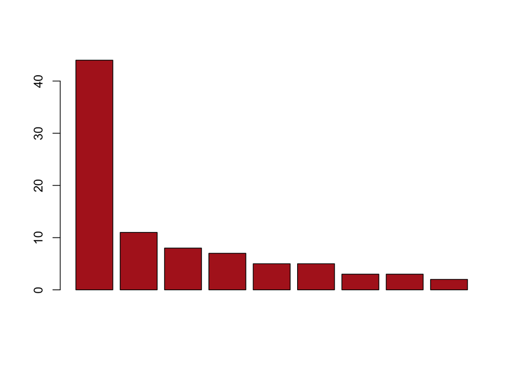

```r
barplot(tiger.table.df$Frequency, col = "firebrick")
```

Well that’s a good start, but where are the axis and category labels? And why does the first bar exceed the range of the y-axis?

Let’s fix these up per the figure. Adding the text annotations is a bit tricky, since the category labels are at a 45 degree angle. We also need to increase the bottom margin, or else the text will get truncated (you can check this for yourself below by commenting out the first `par()` command).

Below, we’ve added all of these bells and whistles for you. Just **paste your barplot command** in the space provided, with one change: set the limits of the y-axis using `ylim = c(0.50))`, to keep the bars in range of the axis tick marks.

Note that we also need to assign the plot to a variable so we can refer to it when we add the text annotations.

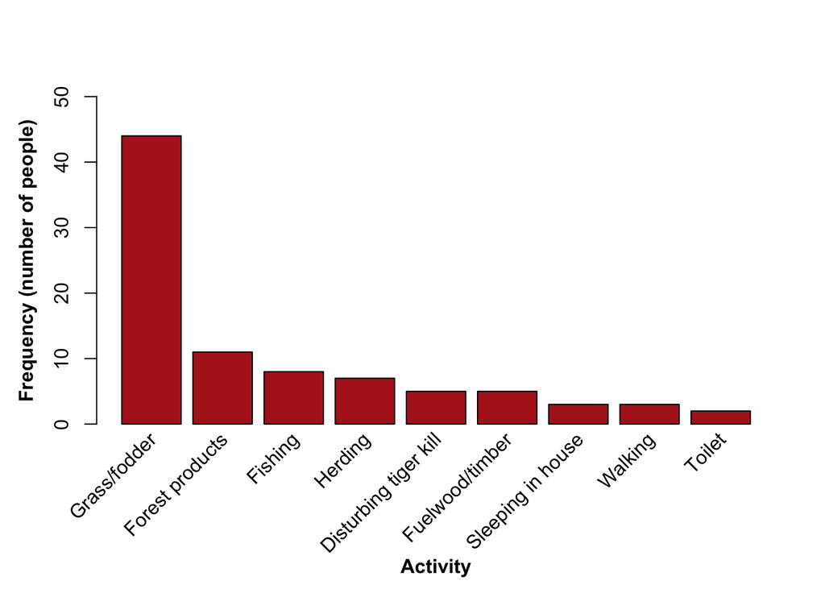

```r
# ============================================================================ #
# 0. open a handle for writing the file
#pdf("test.pdf")

# ============================================================================ #
# 1. increase bottom canvas margin
par(mar=c(7, 4.1, 4.1, 2.1))  # default is par(mar=c(5.1, 4.1, 4.1, 2.1))

# ============================================================================ #
# 2. make a barplot: paste your code here, adding y-axis limits)
tiger.barplot = barplot(tiger.table.df$Frequency,
                         col = "firebrick",
                         ylim = c(0,50))     # y-axis range 0-50

# ============================================================================ #
# 3. add text annotations
## set text at a 45 degree angle and position it relative to the x-axis
text(x = tiger.barplot + 0.25, y = -2,       # x, y positions
     tiger.table.df$Activity,                # Activity factor
     srt = 45, pos = 2,                      # angle and position
     xpd = TRUE )                            # allow text outside plotting area

# ============================================================================ #
# 4. add axis labels
## Arguments: text, bold font, side (1=x-axis,2=y-axis), position
mtext ("Activity", font=2, side=1, line=5.5)
mtext ("Frequency (number of people)", font=2, side=2, line=2.5)
```

```r
# ============================================================================ #
# 5. restore default margins (otherwise changes are persistent)
par(mar=c(5.1, 4.1, 4.1, 2.1))
#par("mar")  # check margins

# ============================================================================ #
# 6. close the device
#dev.off()
```

Nice! How would you save this to a PDF file? Easy peasy! Just surround the code in the block above with `pdf("tigers_freq_plot.pdf")` and `dev.off()`. Do this now. Don’t forget to add some comments!

[Note: since you are opening a new “device”, you don’t need to reset the margins manually, since the overrides will only apply to that device, but it doesn’t hurt anything if you do. You could also set the dimensions and aspect ratio of the output, but this is good enough for us for now.]

### I.2.B) Bar chart with ggplot2

That was kind of tedious, wasn’t it! Let’s redo the bar chart using ggplot2. We can do all of the fancy stuff in one go.

Below, add the **data**, **aesthetics**, and **geom** parts of the plot below:

- Add the `data =` and `aes(x = , y = )` arguments with the appropriate variables.
- Add the `geom_bar()` argument, setting `fill = "firebrick"` and adding `stat = "identity"` inside the parentheses.
- Assign the plot to an object called `my.ggplot` (you’ll see why below)
- Print the object.

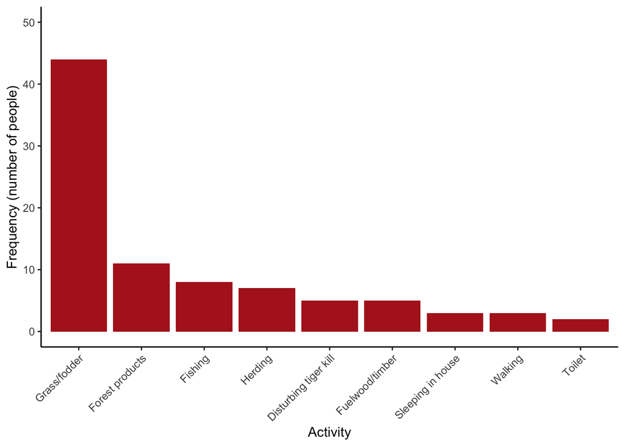

```r
# ============================================================================ #
# add data, aes, and geom
my.ggplot = ggplot(data = tiger.table.df, aes(x = Activity, y = Frequency)) +
  geom_bar(stat = "identity", fill = "firebrick") +
  labs(x = "Activity", y = "Frequency (number of people)") +
  theme_classic() +
  theme(axis.text.x = element_text(angle = 45, hjust = 1)) +
  ylim(c(0,50))

# ============================================================================ #
# show it
my.ggplot
```

Voilà! It’s magic!

### I.2.C) Saving plots to files

To write this ggplot graph to a file, all you have to do is use the `ggsave()` command with a file name and the name of the object you want to print. It will try to guess the type of file you want from the suffix you give it. Try this below.

[Note: If no object is specified, this function will just use the the last plot you made.]

```r
# save it to a PDF file
ggsave("test.ggplot.pdf", plot = my.ggplot)
```

With a named plot, you could also just use the base R methods to save the file by opening a device, printing the object using the `print()` command, and then closing the device. Try this below.

```r
png("my.ggplot_v2.png") # open a PNG device
print(my.ggplot)     # print the plot
dev.off()         # close the device
## quartz_off_screen
##                 2
```

Note that the PNG file has lower resolution using this method. This can be fixed by adding a bunch of extra parameters, but why bother when you can use ggplot?

# II. Numerical data

## II.1) Histogram (frequency distribution)

Let’s reproduce the histogram shown in Figure 2.2-5, which shows the frequency distribution of body mass for 228 female sockeye salmon from Pick Creek, Alaska in 1996, using the data in the corresponding `.csv` file.

Read the file into a data frame called `salmonSizeData` and take a look at it.

```r
salmonSizeData <- read.csv("data/Fig2.2-5_SalmonBodySize.csv")
str(salmonSizeData)
## 'data.frame':    228 obs. of  5 variables:
##  $ year         : int  1996 1996 1996 1996 1996 1996 1996 1996 1996 1996 ...
##  $ sex          : logi  FALSE FALSE FALSE FALSE FALSE FALSE ...
##  $ oceanAgeYears: int  3 3 3 3 3 3 2 2 2 2 ...
##  $ lengthMm     : int  513 513 525 501 513 501 427 457 427 447 ...
##  $ massKg       : num  3.09 2.91 3.06 2.69 2.88 ...
```

## II.1.A) Histogram in base R

Histograms are really easy to make in base R, and it’s really convenient to use them for data exploration.

First, make a histogram of the `massKg` column below.

- Use the same “firebrick” color as before, and label the x-axis with the same label as the figure in the book.

Then, remake the same plot, but make the following additions:

- Use the `breaks` parameter to specify the total number of breaks you would need in order to set the bin size (interval width) to 0.1.
- Set the x-axis range from 1-4 using `xlim`, and the y-axis range from 0-30 using `ylim`
  - [Hint: the range should be a two-element vector]
- Add a nicer main title for the whole plot, e.g. “Salmon Size Distribution”

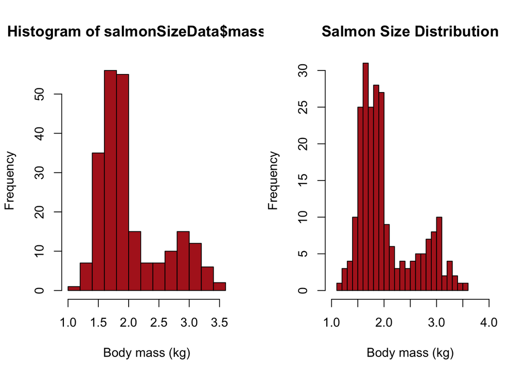

```r
# ============================================================================ #
# make two side-by-side graphs
par(mfrow=c(1,2))

# ============================================================================ #
# Draw a histogram showing frequency data for body mass (base R)
hist(salmonSizeData$massKg,
     col="firebrick",
     xlab = "Body mass (kg)")

# ============================================================================ #
# replot with bin size (interval width) = 0.1
hist(salmonSizeData$massKg,
     col="firebrick",
     breaks = 20, # number of breaks that corresponds to bin width = 0.1
     xlim = c(1,4),
     ylim = c(0,30),
     xlab = "Body mass (kg)",
     main = "Salmon Size Distribution")
```

To visualize the difference between these two plots, let’s draw them side-by-side using the `par()` and setting `mfrow()` to one row and two columns. Add this to the code block above (don’t forget to add comments!).

## II.1.B) Histogram in ggplot2

Now let’s reproduce these plots using ggplot2. First, make a histogram using `qplot()`.

- For the first argument, use mass column from the data frame (this is your “aesthetic mapping”, i.e. the data you want to show)
- For `data`, use the data frame
- You’ll need to set the colors manually by adding: `col=I("black"), fill=I("firebrick")` (I don’t know why the `I()` function is required, but it is)

Then make the same plot one using `ggplot()`. The syntax is different, but you will still be using the data frame as the data, the mass column as the aesthetic mapping, and the histogram as the geometry.

- To get the right coloring scheme, you’ll need to use both the `fill` and `col` parameters to get this right.
- HOWEVER, because you are not mapping any DATA to these aesthetics, you need to set these manually, and put them inside the `geom` layer. Play around with these until you get them right.
- (Note that for ggplot, you do NOT use the `I()` function; why? I don’t know)

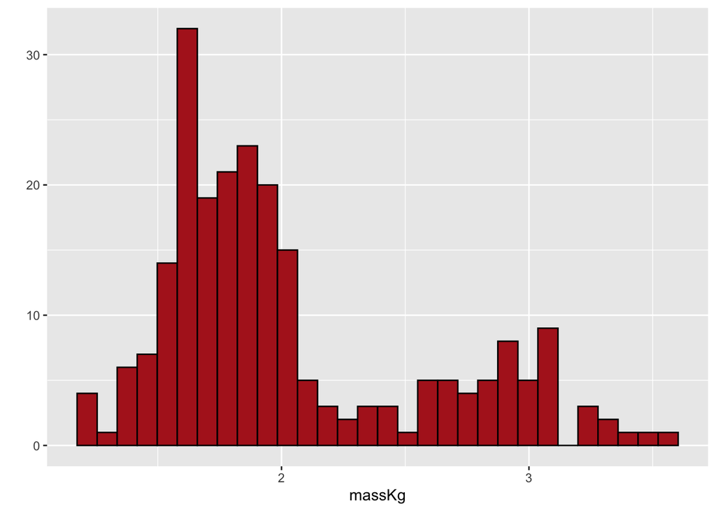

```r
# ============================================================================ #
# quick plot (shortcut), with no special formatting
qplot(x = massKg,
      data = salmonSizeData, geom = "histogram", col=I("black"), fill=I("firebrick"))
```

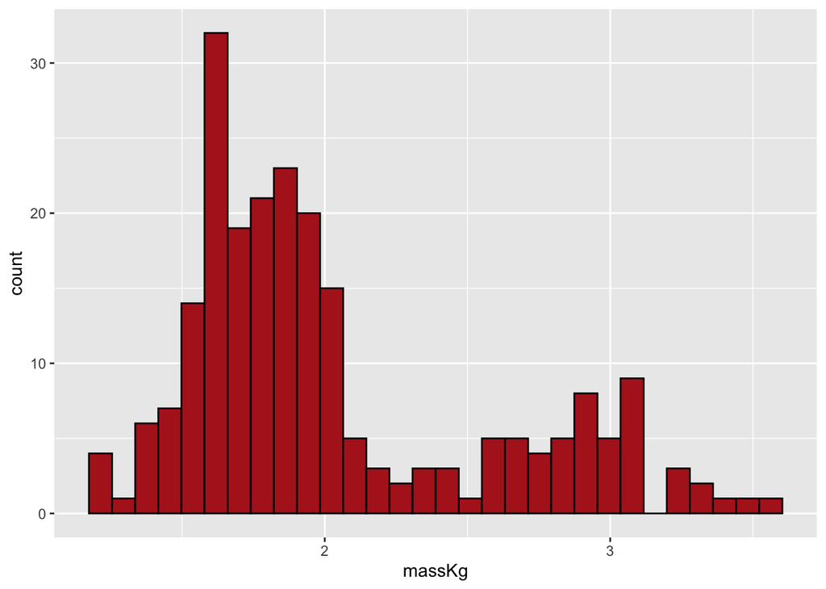

```r
# ============================================================================ #
# body mass histogram with ggplot
ggplot(data = salmonSizeData, mapping = aes(x = massKg)) +
  geom_histogram(fill = "firebrick", col = "black")
```

Notice that you get an error about the number of bins - by default, the number of bins is set to 30, but you’ll usually want to pick a better number for `bins` or set `binwidth`.

## II.1.C) Extra credit

Try to make the second plot look just like the one in the book:

- set `binwidth=0.1`
- set `xlim` (x-axis range)
- use `theme_classic()`
- add some axis tick mark labels
- add axis titles

You’ll also need a couple extra parameters inside the `geom` layer to get the placement of the bars correct. To do this, add `boundary = 0, closed = "left"` inside the geom layer as well.

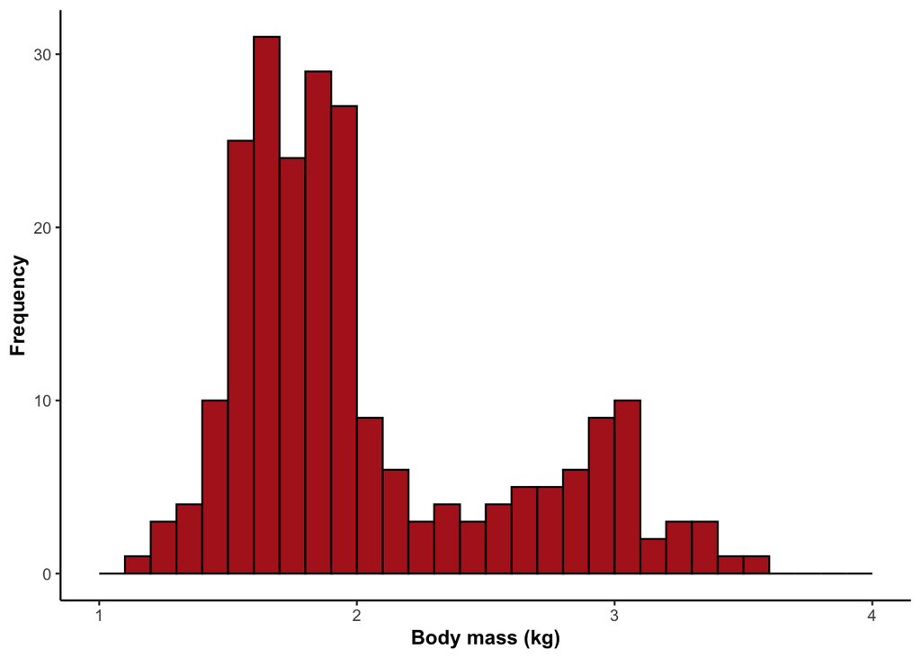

```r
# ============================================================================ #
# fancy plot matching the book
ggplot(data = salmonSizeData, aes(x = massKg)) +
  geom_histogram(fill = "firebrick", col = "black", binwidth = 0.1,
                 boundary = 0, closed = "left") +
  labs(x = "Body mass (kg)", y = "Frequency") +
  xlim(1,4) +
  theme_classic() +
  theme(axis.title.x = element_text(face="bold"),
        axis.title.y = element_text(face="bold"))
```

# III. Associations between variables

## III.1) Two categorical variables

In this exercise, we will reproduce Figure 2.3-1 and Figure 2.3-2 from Example 2.3A in the textbook. The data describe the incidence in malaria in wild birds subjected to reproductive stress by removing eggs from the nest.

We will first produce a side-by-side bar chart, and then a mosaic plot.

Before we start, let’s load the data in the corresponding `.csv` file and check the result. Since some of the data we are interested in should not be interpreted as a factor, make sure you don’t make character columns into factors by accident.

```r
avianMalaria <- read.csv("data/Ex2.3A_malaria.csv", stringsAsFactors = FALSE)
str(avianMalaria) # structure
```

```
## 'data.frame':    65 obs. of  3 variables:
##  $ bird     : int  1 2 3 4 5 6 7 8 9 10 ...
##  $ treatment: chr  "Control" "Control" "Control" "Control" ...
##  $ response : chr  "Malaria" "Malaria" "Malaria" "Malaria" ...
```

```r
head(avianMalaria) # contents (first 6 lines)
```

```
##   bird treatment response
## 1    1   Control  Malaria
## 2    2   Control  Malaria
## 3    3   Control  Malaria
## 4    4   Control  Malaria
## 5    5   Control  Malaria
## 6    6   Control  Malaria
```

Next, let’s use `table()` to make a contingency table of response vs. treatment called `avianMalaria.table`. We then add **marginal** totals, i.e. total counts across each row and column (we have done this for you below).

```r
# ============================================================================ #
# Make a contingency table
avianMalaria.table = table(avianMalaria$response, avianMalaria$treatment)

# ============================================================================ #
# add "marginal" totals
addmargins(avianMalaria.table, margin = c(1,2), FUN = sum, quiet = TRUE)
```

```
##
##              Control Egg removal sum
##   Malaria          7          15  22
##   No Malaria      28          15  43
##   sum             35          30  65
```

## III.1.A) Bar chart with Base R

The default is to make a stacked bar chart. Do this first, using the table you just made. Then modify the code to make a side-by-side plot.

You can make it look approximately like the one in the book by uncommenting the extra lines below and enclosing them in the parentheses (don’t forget to add a comma after the first argument). This adds some space between the bars, some color, and a legend.

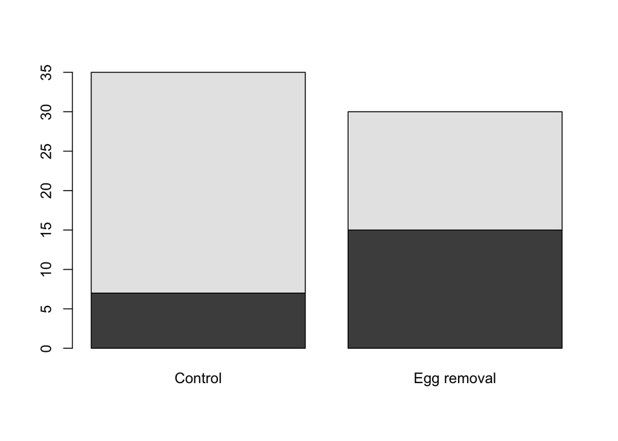

```r
# ============================================================================ #
# stacked
barplot(avianMalaria.table)
```

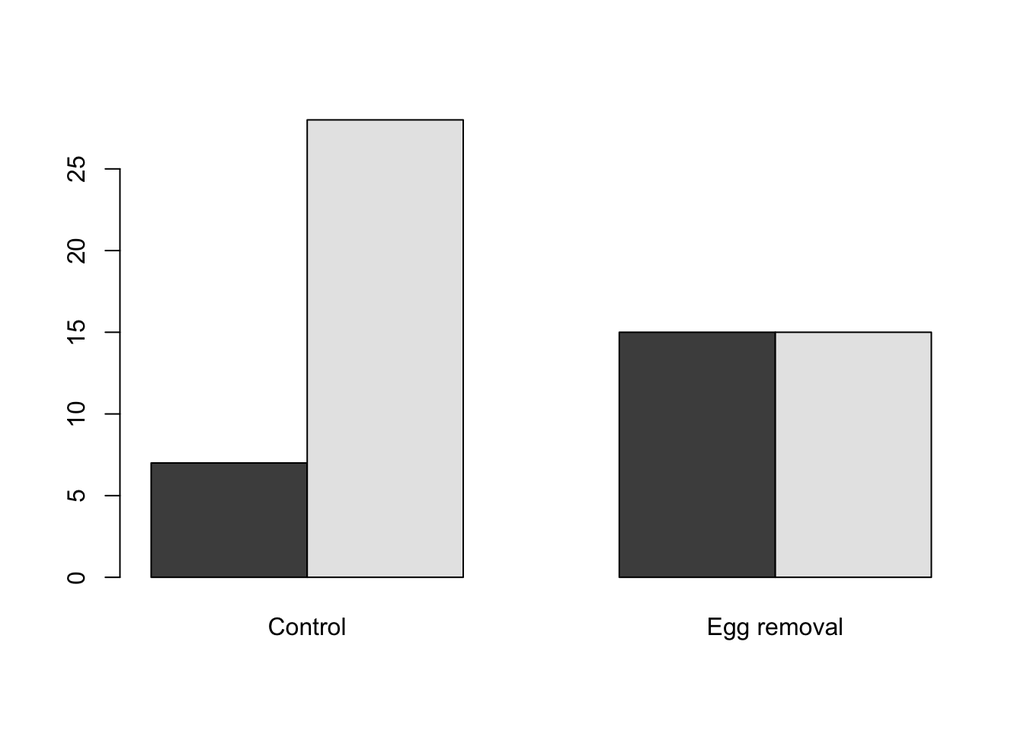

```r
# ============================================================================ #
# side-by-side
barplot(avianMalaria.table, beside=TRUE)
```

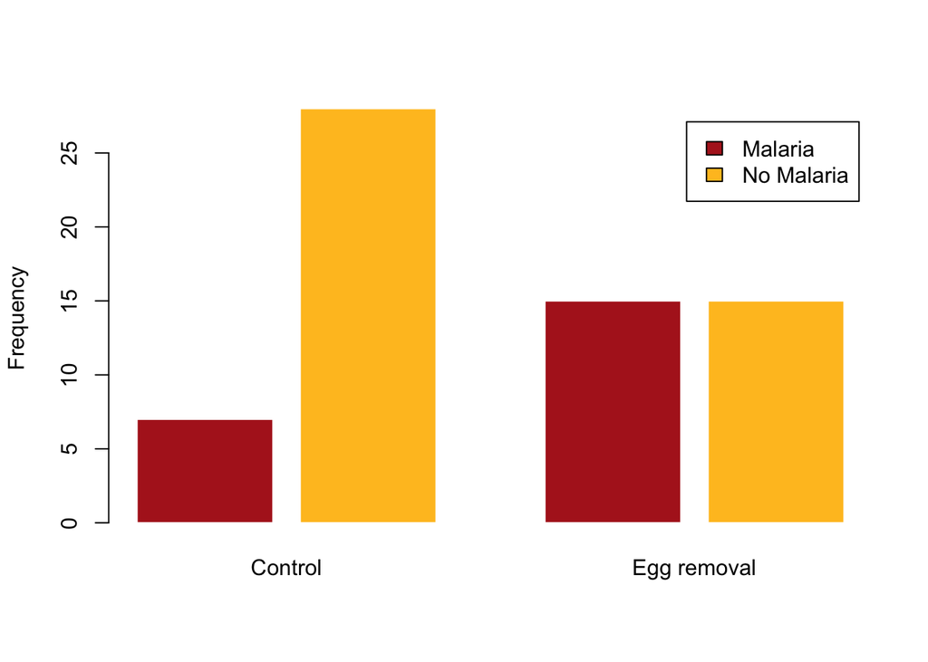

```r
# ============================================================================ #
# a prettier plot (uncomment and append to your basic command)

#         ylab = "Frequency",
#         beside=TRUE,
#         space = c(0.2,0.2,0.8,0.2),
#         col = c("firebrick","goldenrod1"),
#         border=FALSE,
#         legend.text=TRUE

barplot(avianMalaria.table,
        ylab = "Frequency",
        beside=TRUE,
        space = c(0.2,0.2,0.8,0.2),
        col = c("firebrick","goldenrod1"),
        border=FALSE,
        legend.text=TRUE
)
```

## III.1.B) Grouped bar chart with ggplot

Now use ggplot to make a side-by-side bar chart. Note that the default is still to stack bars, so you’ll need another parameter to change this behavior.

- Aesthetics: map the “treatment” variable to `x` and use `fill` for the “response” variable
- Geom: use `position` to control the placement of bars

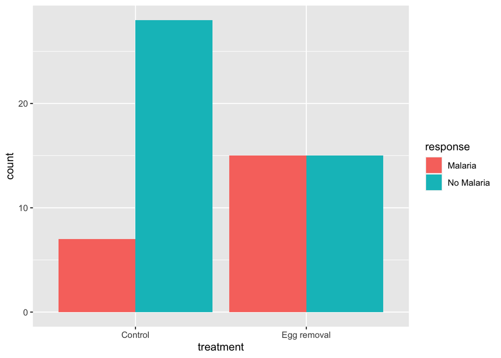

```r
# simple side-by-side plot with default colors
ggplot(avianMalaria, aes(x = treatment, fill = response)) +
  geom_bar(position = "dodge")
```

```r
# ============================================================================ #
# add the code below to your basic command to approximate the figure in the book

  # geom_bar(position = position_dodge2(preserve="single")) +
  # scale_fill_manual(values=c("firebrick", "goldenrod1")) +
  # labs(x = "Treatment", y = "Frequency") +
  # scale_y_continuous(breaks = seq(from = 0, to = 25, by = 5)) + # y-axis
  # theme_classic() +
  # theme(legend.title = element_blank())
```

## III.1.C) Mosaic plot with base R

First, make a basic `mosaciplot()` using the malaria table.

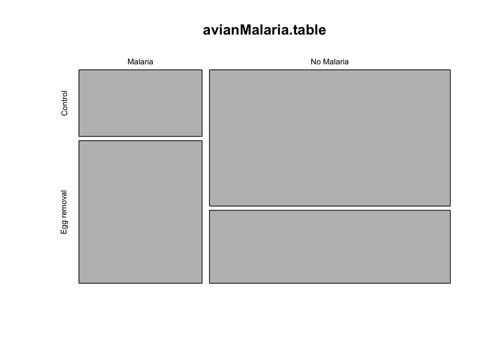

```r
mosaicplot( avianMalaria.table)
```

Why doesn’t this look the same as in the figure? It seems that the axes are flipped!

To make this work the way we want, we can use the transpose function `t()` to flip the table, and then plot it. Try this below.

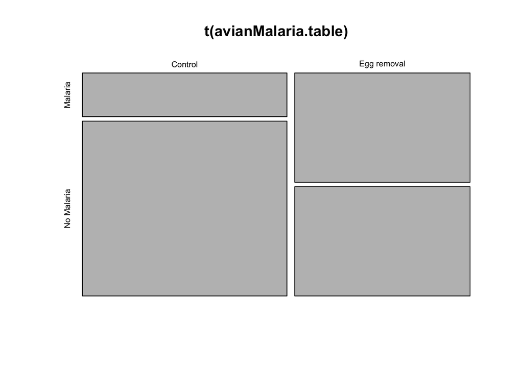

```r
# mosaic plot with transposed table
mosaicplot( t(avianMalaria.table))
```

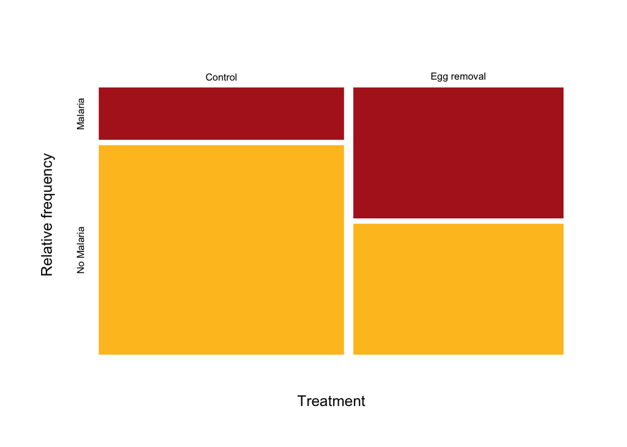

```r
# ============================================================================ #
# uncomment the code below and add it to your basic command to approximate the figure

            # col = c("firebrick", "goldenrod1"),
            # sub = "Treatment",
            # ylab = "Relative frequency",
            # border=FALSE,
            # main = ""

mosaicplot( t(avianMalaria.table),
            col = c("firebrick", "goldenrod1"),
            sub = "Treatment",
            ylab = "Relative frequency",
            border=FALSE,
            main = "")
```

## III.2) Two numerical variables

Are the length and mass of sockeye salmon correlated? Let’s go back to our salmon dataset and see.

### III.2.A) Base R

Use the `plot()` command to make a scatterplot.

- Place the size on the x-axis and the mass on the y-axis.
- Color the points in “firebrick”, and some axis labels as well.

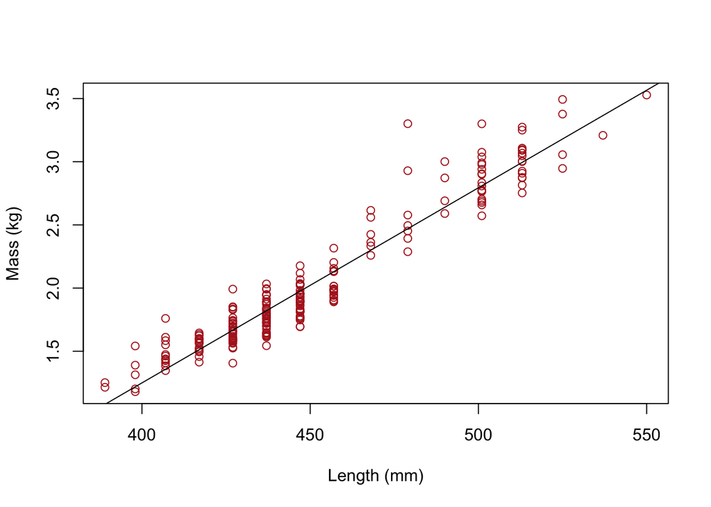

```r
# Make a scatterplot of length and mass
plot(salmonSizeData$lengthMm,
     salmonSizeData$massKg,
     col="firebrick",
     xlab="Length (mm)",
     ylab="Mass (kg)" )

# add the best-fit regression line for these data
# (execute as a single code block to see the result)
abline(lm(massKg ~ lengthMm, data = salmonSizeData))
```

### III.2.B) ggplot2

Scatterplots use the `geom_point()` geometry. Map the salmon data onto the x- and y-axes as above.

- Inside the `geom` layer, you can manually set the `size` and `col` (color) of the points; use `shape=1` to get hollow points
- Add axis labels as above
- To add a simple regression line, add a `stat` layer: `stat_smooth(method=lm, se=FALSE, color="black")`
- Add `theme_classic()` to get a white background

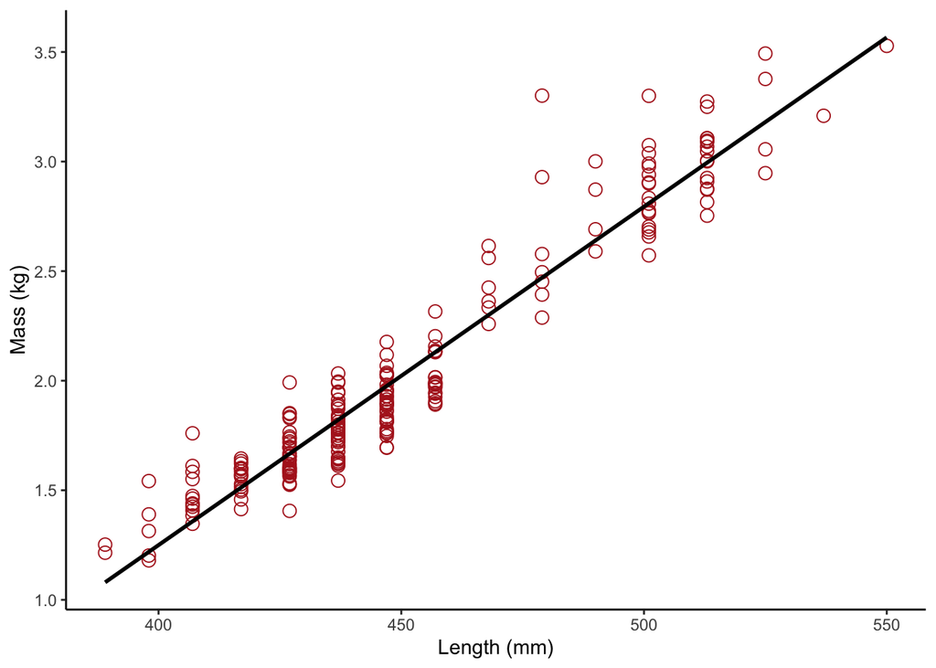

```r
ggplot(data = salmonSizeData, aes(x = lengthMm, y = massKg)) +
  geom_point(size = 3, col = "firebrick", shape=1)  +
  labs(x = "Length (mm)", y = "Mass (kg)") +
  theme_classic() +
  stat_smooth(method=lm, se=FALSE, color="black")
```